# **Analyse de données d’écologie forestière dans le bois de Montrond**

Dynamique de l’organisation structurelle des arbres en forêt

Mathis LEHMANN, Elodie MANZANO, Celia WOTLING, Titouan HUET

2023-05-10

# 1 Charger des librairies et des fichiers

```r
library(ggplot2)
library(dplyr)
library(car)
library(tidyverse)
circonf<-read.csv("Circonf.csv")
```

#Etude des arbres morts

Le principe de cette étude est de caractériser la dynamique d’âge et de structure des arbres dans la forêt. Ici, on a mesuré la circonférence des arbres, qui est un proxi de l’âge des arbres. Il aurait fallu concentrer cette étude sur une seule espèce d’arbres pour avoir des résultats totalement interprétables, mais : -une grande variation de la biodiversité est observée entre les différentes placettes, selon la topographie et l’exposition. Certaines espèces sont notamment absentes de certains endroits. -se concentrer sur 1 seule espèce aurait réduit considérablement le nombre de mesures, ce qui aurait rendu les données inexploitables. -certains arbres (arbres morts uniquement) n’ont pas été attribués à 1 espèce en particulier car il a été difficile de les identifier. Nous mélangeons donc les espèces dans cette étude, il faudra donc lire les résultats à la lumière du fait que plusieurs espèces sont mélangées.

Tout d’abord, représentons la distribution des circonférences mesurées, en fonction des paramètres étudiés.

```r
circonf$Topo <- factor(circonf$Topo, levels=c("HDP","MDP","BDP"))
medV <- circonf %>%
  group_by(Etat,Topo,Exposition) %>%
  summarize(mean_x = mean(Circonference))
```

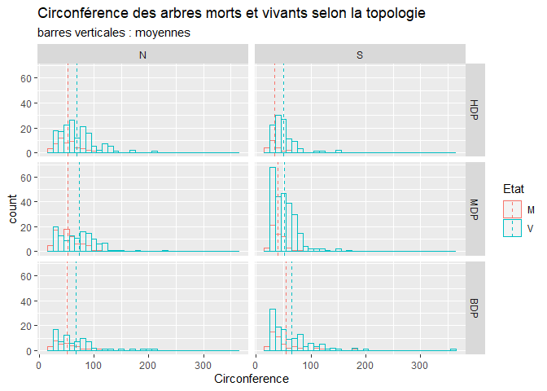

```r
p<- ggplot(circonf, aes(x=Circonference, color=Etat))+geom_histogram(fill="white", alpha=0.1, position="identity",binwidth=10,)+facet_grid(Topo ~Exposition)
p+geom_vline(data=medV, aes(xintercept=mean_x, color=Etat),linetype="dashed") +ggtitle("Circonférence des arbres morts et vivants selon la topologie", "barres verticales : moyennes")
```

Ainsi, on observe différentes distributions. Pour étudier les différentes dynamiques, il va falloir montrer que ces distributions sont statistiquement différentes les unes des autres. Or, elles ne correspondent pas à des distributions connues, on va donc comparer leurs paramètres : moyenne et variance. Pour ce faire, on va utiliser un test de Wilcoxon pour comparer les moyennes des distributions 2 à 2, et un test de Levene pour faire de même avec les variances.

Plusieurs données statistiques (variance, moyenne, rapport des variances et coefficient de variation, pour les morts et les vivants) sont présentés dans le data frame InfosVarianceMoyenne codé ci-dessous :

```r
var_et_moy2<-function(Expo, Top) {
  varianceVivants<-var(circonf[circonf$Exposition==Expo & circonf$Topo==Top & circonf$Etat=="V",5])
  moyenneVivants<-mean(circonf[circonf$Exposition==Expo & circonf$Topo==Top & circonf$Etat=="V",5])
  varianceMorts<-var(circonf[circonf$Exposition==Expo & circonf$Topo==Top & circonf$Etat=="M",5])
  moyenneMorts<-mean(circonf[circonf$Exposition==Expo & circonf$Topo==Top & circonf$Etat=="M",5])
  topo<-circonf[circonf$Exposition==Expo & circonf$Topo==Top & circonf$Etat=="V",3][1]
  expo<-circonf[circonf$Exposition==Expo & circonf$Topo==Top & circonf$Etat=="V",4][1]
  RapVar<-varianceVivants/varianceMorts
  RapMoy<-moyenneVivants/moyenneMorts
  CoefVarViv<-varianceVivants/moyenneVivants
  CoefVarMort<-varianceMorts/moyenneMorts
  return(c(varianceVivants, varianceMorts,moyenneVivants,moyenneMorts,RapVar,RapMoy,CoefVarViv,CoefVarMort,Top,Expo))
}


a<-var_et_moy2("N","HDP")
b<-var_et_moy2("N","MDP")
d<-var_et_moy2("N","BDP")
e<-var_et_moy2("S","HDP")
f<-var_et_moy2("S","MDP")
g<-var_et_moy2("S","BDP")

abdefg<-c(a,b,d,e,f,g)

InfosVarianceMoyenne<-data.frame(a,b,d,e,f,g)

row.names(InfosVarianceMoyenne)[1:10]<-c("VarVivant","VarMort","MoyVivant","MoyMort","RaportVar","RaportMoy","CoefVarViv","CoefVarMort","Topo","Expo")
InfosVarianceMoyenne<-t(InfosVarianceMoyenne)
InfosVarianceMoyenne<-data.frame(InfosVarianceMoyenne)
InfosVarianceMoyenne[,1]=as.numeric(as.character(InfosVarianceMoyenne[,1]))
InfosVarianceMoyenne[,2]=as.numeric(as.character(InfosVarianceMoyenne[,2]))
InfosVarianceMoyenne[,3]=as.numeric(as.character(InfosVarianceMoyenne[,3]))
InfosVarianceMoyenne[,4]=as.numeric(as.character(InfosVarianceMoyenne[,4]))
InfosVarianceMoyenne[,5]=as.numeric(as.character(InfosVarianceMoyenne[,5]))
InfosVarianceMoyenne[,6]=as.numeric(as.character(InfosVarianceMoyenne[,6]))
```

Voici le code des tests de Wilcoxon :

```r
#Définition des data frame tronqués aux valeurs pour comparer deux à deux.

#Haut de pente, nord, mort versus vivant
CirHDPN<-subset(circonf,Topo=='HDP'&Exposition=="N" )
tapply(CirHDPN$Circonference,CirHDPN$Etat,mean)
```

```
##        M        V
## 51.73469 69.38065
```

```r
wilcox.test(Circonference~Etat, data=CirHDPN)
```

```
##
##  Wilcoxon rank sum test with continuity correction
##
## data:  Circonference by Etat
## W = 2568, p-value = 0.0006125
## alternative hypothesis: true location shift is not equal to 0
```

```r
#Haut de pente, sud, mort versus vivant
CirHDPS<-subset(circonf,Topo=='HDP'&Exposition=="S" )
tapply(CirHDPS$Circonference,CirHDPS$Etat,mean)
```

```
##        M        V
## 34.14286 49.81132
```

```r
wilcox.test(Circonference~Etat, data=CirHDPS)
```

```
##
##  Wilcoxon rank sum test with continuity correction
##
## data:  Circonference by Etat
## W = 437.5, p-value = 8.681e-06
## alternative hypothesis: true location shift is not equal to 0
```

```r
#Milieu de pente, nord, mort versus vivant
CirMDPN<-subset(circonf,Topo=='MDP'&Exposition=="N" )
tapply(CirMDPN$Circonference,CirMDPN$Etat,mean)
```

```
##        M        V
## 51.84524 72.64800
```

```r
wilcox.test(Circonference~Etat, data=CirMDPN)
```

```
##
##  Wilcoxon rank sum test with continuity correction
##
## data:  Circonference by Etat
## W = 3292.5, p-value = 4.773e-06
## alternative hypothesis: true location shift is not equal to 0
```

```r
#Milieu de pente, sud, mort versus vivant
CirMDPS<-subset(circonf,Topo=='MDP'&Exposition=="S" )
tapply(CirMDPS$Circonference,CirMDPS$Etat,mean)
```

```
##        M        V
## 40.23636 52.20233
```

```r
wilcox.test(Circonference~Etat, data=CirMDPS)
```

```
##
##  Wilcoxon rank sum test with continuity correction
##
## data:  Circonference by Etat
## W = 4744, p-value = 0.0001086
## alternative hypothesis: true location shift is not equal to 0
```

```r
#Bas de pente, nord, mort versus vivant
CirBDPN<-subset(circonf,Topo=='BDP'&Exposition=="N" )
tapply(CirBDPN$Circonference,CirBDPN$Etat,mean)
```

```
##        M        V
## 51.27273 67.14667
```

```r
wilcox.test(Circonference~Etat, data=CirBDPN)
```

```
##
##  Wilcoxon rank sum test with continuity correction
##
## data:  Circonference by Etat
## W = 905.5, p-value = 0.0262
## alternative hypothesis: true location shift is not equal to 0
```

```r
#Bas de pente, sud, mort versus vivant
CirBDPS<-subset(circonf,Topo=='BDP'&Exposition=="S" )
tapply(CirBDPS$Circonference,CirBDPS$Etat,mean)
```

```
##        M        V
## 54.02041 64.94444
```

```r
wilcox.test(Circonference~Etat, data=CirBDPS)
```

```
##
##  Wilcoxon rank sum test with continuity correction
##
## data:  Circonference by Etat
## W = 2565.5, p-value = 0.08139
## alternative hypothesis: true location shift is not equal to 0
```

```r
#Entre Haut et bas, nord, mort
CirNMH_B<-subset(circonf,Etat=="M"&Exposition=="N"&(Topo=='BDP'|Topo=='HDP') )
tapply(CirNMH_B$Circonference,CirNMH_B$Topo,mean)
```

```
##      HDP      MDP      BDP
## 51.73469       NA 51.27273
```

```r
wilcox.test(Circonference~Topo, data=CirNMH_B)
```

```
##
##  Wilcoxon rank sum test with continuity correction
##
## data:  Circonference by Topo
## W = 874, p-value = 0.5385
## alternative hypothesis: true location shift is not equal to 0
```

```r
#Entre Haut et milieu, nord, mort
CirNMH_M<-subset(circonf,Etat=="M"&Exposition=="N"&(Topo=='MDP'|Topo=='HDP') )
tapply(CirNMH_M$Circonference,CirNMH_M$Topo,mean)
```

```
##      HDP      MDP      BDP
## 51.73469 51.84524       NA
```

```r
wilcox.test(Circonference~Topo, data=CirNMH_M)
```

```
##
##  Wilcoxon rank sum test with continuity correction
##
## data:  Circonference by Topo
## W = 2105, p-value = 0.8282
## alternative hypothesis: true location shift is not equal to 0
```

```r
#Entre Bas et milieu, nord, mort
CirNMB_M<-subset(circonf,Etat=="M"&Exposition=="N"&(Topo=='MDP'|Topo=='BDP') )
tapply(CirNMB_M$Circonference,CirNMB_M$Topo,mean)
```

```
##      HDP      MDP      BDP
##       NA 51.84524 51.27273
```

```r
wilcox.test(Circonference~Topo, data=CirNMB_M)
```

```
##
##  Wilcoxon rank sum test with continuity correction
##
## data:  Circonference by Topo
## W = 1478, p-value = 0.5792
## alternative hypothesis: true location shift is not equal to 0
```

```r
#Entre Haut et Bas, sud, mort
CirSMH_B<-subset(circonf,Etat=="M"&Exposition=="S"&(Topo=='BDP'|Topo=='HDP') )
tapply(CirSMH_B$Circonference,CirSMH_B$Topo,mean)
```

```
##      HDP      MDP      BDP
## 34.14286       NA 54.02041
```

```r
wilcox.test(Circonference~Topo, data=CirSMH_B)
```

```
##
##  Wilcoxon rank sum test with continuity correction
##
## data:  Circonference by Topo
## W = 261.5, p-value = 0.0012
## alternative hypothesis: true location shift is not equal to 0
```

```r
#Entre Haut et Milieu, sud, mort
CirSMH_M<-subset(circonf,Etat=="M"&Exposition=="S"&(Topo=='MDP'|Topo=='HDP') )
tapply(CirSMH_M$Circonference,CirSMH_M$Topo,mean)
```

```
##      HDP      MDP      BDP
## 34.14286 40.23636       NA
```

```r
wilcox.test(Circonference~Topo, data=CirSMH_M)
```

```
##
##  Wilcoxon rank sum test with continuity correction
##
## data:  Circonference by Topo
## W = 358.5, p-value = 0.01105
## alternative hypothesis: true location shift is not equal to 0
```

```r
#Entre Milieu et Bas, sud, mort
CirSMB_M<-subset(circonf,Etat=="M"&Exposition=="S"&(Topo=='MDP'|Topo=='BDP') )
tapply(CirSMB_M$Circonference,CirSMB_M$Topo,mean)
```

```
##      HDP      MDP      BDP
##       NA 40.23636 54.02041
```

```r
wilcox.test(Circonference~Topo, data=CirSMB_M)
```

```
##
##  Wilcoxon rank sum test with continuity correction
##
## data:  Circonference by Topo
## W = 1101, p-value = 0.1089
## alternative hypothesis: true location shift is not equal to 0
```

```r
#Entre Haut et bas, nord, vivant
CirNVH_B<-subset(circonf,Etat=="V"&Exposition=="N"&(Topo=='BDP'|Topo=='HDP') )
tapply(CirNVH_B$Circonference,CirNVH_B$Topo,mean)
```

```
##      HDP      MDP      BDP
## 69.38065       NA 67.14667
```

```r
wilcox.test(Circonference~Topo, data=CirNVH_B)
```

```
##
##  Wilcoxon rank sum test with continuity correction
##
## data:  Circonference by Topo
## W = 6442, p-value = 0.1804
## alternative hypothesis: true location shift is not equal to 0
```

```r
#Entre Haut et milieu, nord, vivant
CirNVH_M<-subset(circonf,Etat=="V"&Exposition=="N"&(Topo=='MDP'|Topo=='HDP') )
tapply(CirNVH_M$Circonference,CirNVH_M$Topo,mean)
```

```
##      HDP      MDP      BDP
## 69.38065 72.64800       NA
```

```r
wilcox.test(Circonference~Topo, data=CirNVH_M)
```

```
##
##  Wilcoxon rank sum test with continuity correction
##
## data:  Circonference by Topo
## W = 9070.5, p-value = 0.3571
## alternative hypothesis: true location shift is not equal to 0
```

```r
#Entre Bas et milieu, nord, vivant
CirNVB_M<-subset(circonf,Etat=="V"&Exposition=="N"&(Topo=='MDP'|Topo=='BDP') )
tapply(CirNVB_M$Circonference,CirNVB_M$Topo,mean)
```

```
##      HDP      MDP      BDP
##       NA 72.64800 67.14667
```

```r
wilcox.test(Circonference~Topo, data=CirNVB_M)
```

```
##
##  Wilcoxon rank sum test with continuity correction
##
## data:  Circonference by Topo
## W = 5429.5, p-value = 0.05952
## alternative hypothesis: true location shift is not equal to 0
```

```r
#Entre Haut et Bas, sud, vivant
CirSVH_B<-subset(circonf,Etat=="V"&Exposition=="S"&(Topo=='BDP'|Topo=='HDP') )
tapply(CirSVH_B$Circonference,CirSVH_B$Topo,mean)
```

```
##      HDP      MDP      BDP
## 49.81132       NA 64.94444
```

```r
wilcox.test(Circonference~Topo, data=CirSVH_B)
```

```
##
##  Wilcoxon rank sum test with continuity correction
##
## data:  Circonference by Topo
## W = 5579.5, p-value = 0.02849
## alternative hypothesis: true location shift is not equal to 0
```

```r
#Entre Haut et Milieu, sud, vivant
CirSVH_M<-subset(circonf,Etat=="V"&Exposition=="S"&(Topo=='MDP'|Topo=='HDP') )
tapply(CirSVH_M$Circonference,CirSVH_M$Topo,mean)
```

```
##      HDP      MDP      BDP
## 49.81132 52.20233       NA
```

```r
wilcox.test(Circonference~Topo, data=CirSVH_M)
```

```
##
##  Wilcoxon rank sum test with continuity correction
##
## data:  Circonference by Topo
## W = 12708, p-value = 0.3063
## alternative hypothesis: true location shift is not equal to 0
```

```r
#Entre Milieu et Bas, sud, vivant
CirSVB_M<-subset(circonf,Etat=="V"&Exposition=="S"&(Topo=='MDP'|Topo=='BDP') )
tapply(CirSVB_M$Circonference,CirSVB_M$Topo,mean)
```

```
##      HDP      MDP      BDP
##       NA 52.20233 64.94444
```

```r
wilcox.test(Circonference~Topo, data=CirSVB_M)
```

```
##
##  Wilcoxon rank sum test with continuity correction
##
## data:  Circonference by Topo
## W = 14168, p-value = 0.04361
## alternative hypothesis: true location shift is not equal to 0
```

```r
#Entre nord et sud, HDP, vivant
CirHDPVN_S<-subset(circonf,Etat=="V"&Topo=='HDP')
tapply(CirHDPVN_S$Circonference,CirHDPVN_S$Exposition,mean)
```

```
##        N        S
## 69.38065 49.81132
```

```r
wilcox.test(Circonference~Exposition, data=CirHDPVN_S)
```

```
##
##  Wilcoxon rank sum test with continuity correction
##
## data:  Circonference by Exposition
## W = 11724, p-value = 3.261e-09
## alternative hypothesis: true location shift is not equal to 0
```

```r
#Entre nord et sud, MDP, vivant
CirMDPVN_S<-subset(circonf,Etat=="V"&Topo=='MDP')
tapply(CirMDPVN_S$Circonference,CirMDPVN_S$Exposition,mean)
```

```
##        N        S
## 72.64800 52.20233
```

```r
wilcox.test(Circonference~Exposition, data=CirMDPVN_S)
```

```
##
##  Wilcoxon rank sum test with continuity correction
##
## data:  Circonference by Exposition
## W = 22196, p-value = 8.89e-10
## alternative hypothesis: true location shift is not equal to 0
```

```r
#Entre nord et sud, BDP, vivant
CirBDPVN_S<-subset(circonf,Etat=="V"&Topo=='BDP')
tapply(CirBDPVN_S$Circonference,CirBDPVN_S$Exposition,mean)
```

```
##        N        S
## 67.14667 64.94444
```

```r
wilcox.test(Circonference~Exposition, data=CirBDPVN_S)
```

```
##
##  Wilcoxon rank sum test with continuity correction
##
## data:  Circonference by Exposition
## W = 5053, p-value = 0.4061
## alternative hypothesis: true location shift is not equal to 0
```

```r
#Entre nord et sud, HDP, mort
CirHDPMN_S<-subset(circonf,Etat=="M"&Topo=='HDP')
tapply(CirHDPMN_S$Circonference,CirHDPMN_S$Exposition,mean)
```

```
##        N        S
## 51.73469 34.14286
```

```r
wilcox.test(Circonference~Exposition, data=CirHDPMN_S)
```

```
##
##  Wilcoxon rank sum test with continuity correction
##
## data:  Circonference by Exposition
## W = 812, p-value = 0.0001386
## alternative hypothesis: true location shift is not equal to 0
```

```r
#Entre nord et sud, MDP, mort
CirMDPMN_S<-subset(circonf,Etat=="M"&Topo=='MDP')
tapply(CirMDPMN_S$Circonference,CirMDPMN_S$Exposition,mean)
```

```
##        N        S
## 51.84524 40.23636
```

```r
wilcox.test(Circonference~Exposition, data=CirMDPMN_S)
```

```
##
##  Wilcoxon rank sum test with continuity correction
##
## data:  Circonference by Exposition
## W = 3100, p-value = 0.0006671
## alternative hypothesis: true location shift is not equal to 0
```

```r
#Entre nord et sud, BDP, mort
CirBDPMN_S<-subset(circonf,Etat=="M"&Topo=='BDP')
tapply(CirBDPMN_S$Circonference,CirBDPMN_S$Exposition,mean)
```

```
##        N        S
## 51.27273 54.02041
```

```r
wilcox.test(Circonference~Exposition, data=CirBDPMN_S)
```

```
##
##  Wilcoxon rank sum test with continuity correction
##
## data:  Circonference by Exposition
## W = 834, p-value = 0.813
## alternative hypothesis: true location shift is not equal to 0
```

On obtient : -Les moyennes des morts et des vivants sont, pour chaque condition, statistiquement différentes, à l’exception de la condition BDP sud. Ainsi, dans le versant Nord, les arbres morts ont une circonférence en moyenne 24% à 29% plus petite que celle des arbres vivants. Dans le versant sud, les arbres morts ont une circonférence en moyenne 23% à 31% plus petite que celle des vivants. -Sur le versant Nord, les moyennes ne sont pas différentes entre des arbres d’un même état (morts ou vivants) -Sur le versant sud, on identifie 2 groupes de placettes pour les vivants : les placettes BDP, et les autres, avec des moyennes statistiquement distinctes entre les deux groupes, mais non différentes entre HDP et MDP : les arbres en bas de pente ont des circonférences 23% à 30% plus importante que celle des arbres de milieu ou haut de pente. Pour les morts, on a également deux groupes : les placettes HDP, dont la circonférence des arbres est 15% à 38% plus faible. -En comparant les deux versants, à topographie et état fixés, on constate que les moyennes de circonférences sont statistiquement différentes pour HDP et pour MDP, les arbres du sud ayant une circonférence 30% plus faible, mais pas pour BDP. Cela tend à signifier que l’exposition joue un rôle dans la distribution des circonférences, sauf dans le BDP. On peut donc supposer que l’exposition n’est pas sensible dans le bas de pente, au fond de la vallée. Concernant les différences dans les deux autres topographies, il faudrait mettre ce résultat en perspective avec la distribution des espèces.

Ces tests statistiques nous informent que les distributions ne sont pas toutes identiques, ce qui pourrait être dû à un effet de la topographie et de l’exposition. Pour aller plus loin dans l’analyse, on va chercher à caractériser les distributions en comparant 2 à 2 leur variance par un test de Levene.

Pour s’affranchir d’un potentiel effet de la moyenne, on centre nos valeurs avant d’étudier leur variance.

```r
circ2 <- circonf %>%
  group_by(Placette,Sous_placette,Etat) %>%
  mutate(CirconferenceScale = Circonference - mean(Circonference))
```

```r
#Haut de pente, nord, mort versus vivant
CirHDPN<-subset(circ2,Topo=='HDP'&Exposition=="N" )
leveneTest(CirconferenceScale~Etat, data = CirHDPN)
```

```
## Levene's Test for Homogeneity of Variance (center = median)
##        Df F value   Pr(>F)
## group   1  11.161 0.000995 ***
##       202
## ---
## Signif. codes:  0 '***' 0.001 '**' 0.01 '*' 0.05 '.' 0.1 ' ' 1
```

```r
fligner.test(CirconferenceScale ~ Etat, data = CirHDPN)
```

```
##
##  Fligner-Killeen test of homogeneity of variances
##
## data:  CirconferenceScale by Etat
## Fligner-Killeen:med chi-squared = 11.36, df = 1, p-value = 0.0007506
```

```r
bartlett.test(CirconferenceScale ~ Etat, data = CirHDPN)
```

```
##
##  Bartlett test of homogeneity of variances
##
## data:  CirconferenceScale by Etat
## Bartlett's K-squared = 20.004, df = 1, p-value = 7.728e-06
```

```r
#Haut de pente, sud, mort versus vivant
CirHDPS<-subset(circ2,Topo=='HDP'&Exposition=="S" )
leveneTest(CirconferenceScale~Etat, data = CirHDPS)
```

```
## Levene's Test for Homogeneity of Variance (center = median)
##        Df F value  Pr(>F)
## group   1  3.0074 0.08535 .
##       125
## ---
## Signif. codes:  0 '***' 0.001 '**' 0.01 '*' 0.05 '.' 0.1 ' ' 1
```

```r
fligner.test(CirconferenceScale ~ Etat, data = CirHDPS)
```

```
##
##  Fligner-Killeen test of homogeneity of variances
##
## data:  CirconferenceScale by Etat
## Fligner-Killeen:med chi-squared = 4.4428, df = 1, p-value = 0.03505
```

```r
bartlett.test(CirconferenceScale ~ Etat, data = CirHDPS)
```

```
##
##  Bartlett test of homogeneity of variances
##
## data:  CirconferenceScale by Etat
## Bartlett's K-squared = 12.416, df = 1, p-value = 0.0004256
```

```r
#Milieu de pente, nord, mort versus vivant
CirMDPN<-subset(circ2,Topo=='MDP'&Exposition=="N" )
leveneTest(CirconferenceScale~Etat, data = CirMDPN)
```

```
## Levene's Test for Homogeneity of Variance (center = median)
##        Df F value    Pr(>F)
## group   1  16.735 6.154e-05 ***
##       207
## ---
## Signif. codes:  0 '***' 0.001 '**' 0.01 '*' 0.05 '.' 0.1 ' ' 1
```

```r
fligner.test(CirconferenceScale ~ Etat, data = CirMDPN)
```

```
##
##  Fligner-Killeen test of homogeneity of variances
##
## data:  CirconferenceScale by Etat
## Fligner-Killeen:med chi-squared = 17.063, df = 1, p-value = 3.616e-05
```

```r
bartlett.test(CirconferenceScale ~ Etat, data = CirMDPN)
```

```
##
##  Bartlett test of homogeneity of variances
##
## data:  CirconferenceScale by Etat
## Bartlett's K-squared = 28.628, df = 1, p-value = 8.769e-08
```

```r
#Milieu de pente, sud, mort versus vivant
CirMDPS<-subset(circ2,Topo=='MDP'&Exposition=="S" )
leveneTest(CirconferenceScale~Etat, data = CirMDPS)
```

```
## Levene's Test for Homogeneity of Variance (center = median)
##        Df F value  Pr(>F)
## group   1  6.1099 0.01398 *
##       310
## ---
## Signif. codes:  0 '***' 0.001 '**' 0.01 '*' 0.05 '.' 0.1 ' ' 1
```

```r
fligner.test(CirconferenceScale ~ Etat, data = CirMDPS)
```

```
##
##  Fligner-Killeen test of homogeneity of variances
##
## data:  CirconferenceScale by Etat
## Fligner-Killeen:med chi-squared = 6.671, df = 1, p-value = 0.009799
```

```r
bartlett.test(CirconferenceScale ~ Etat, data = CirMDPS)
```

```
##
##  Bartlett test of homogeneity of variances
##
## data:  CirconferenceScale by Etat
## Bartlett's K-squared = 31.338, df = 1, p-value = 2.168e-08
```

```r
#Bas de pente, nord, mort versus vivant
CirBDPN<-subset(circ2,Topo=='BDP'&Exposition=="N" )
leveneTest(CirconferenceScale~Etat, data = CirBDPN)
```

```
## Levene's Test for Homogeneity of Variance (center = median)
##        Df F value Pr(>F)
## group   1  1.2787 0.2607
##       106
```

```r
fligner.test(CirconferenceScale ~ Etat, data = CirBDPN)
```

```
##
##  Fligner-Killeen test of homogeneity of variances
##
## data:  CirconferenceScale by Etat
## Fligner-Killeen:med chi-squared = 0.98077, df = 1, p-value = 0.322
```

```r
bartlett.test(CirconferenceScale ~ Etat, data = CirBDPN)
```

```
##
##  Bartlett test of homogeneity of variances
##
## data:  CirconferenceScale by Etat
## Bartlett's K-squared = 3.77, df = 1, p-value = 0.05218
```

```r
#Bas de pente, sud, mort versus vivant
CirBDPS<-subset(circ2,Topo=='BDP'&Exposition=="S" )
leveneTest(CirconferenceScale~Etat, data = CirBDPS)
```

```
## Levene's Test for Homogeneity of Variance (center = median)
##        Df F value Pr(>F)
## group   1  2.2682 0.1339
##       173
```

```r
fligner.test(CirconferenceScale ~ Etat, data = CirBDPS)
```

```
##
##  Fligner-Killeen test of homogeneity of variances
##
## data:  CirconferenceScale by Etat
## Fligner-Killeen:med chi-squared = 2.7196, df = 1, p-value = 0.09912
```

```r
bartlett.test(CirconferenceScale ~ Etat, data = CirBDPS)
```

```
##
##  Bartlett test of homogeneity of variances
##
## data:  CirconferenceScale by Etat
## Bartlett's K-squared = 16.312, df = 1, p-value = 5.372e-05
```

```r
#Entre Haut et bas, nord, mort
CirNMH_B<-subset(circ2,Etat=="M"&Exposition=="N"&(Topo=='BDP'|Topo=='HDP') )
leveneTest(CirconferenceScale~Topo, data = CirNMH_B)
```

```
## Levene's Test for Homogeneity of Variance (center = median)
##       Df F value Pr(>F)
## group  1  0.8241 0.3667
##       80
```

```r
fligner.test(CirconferenceScale ~ Topo, data = CirNMH_B)
```

```
##
##  Fligner-Killeen test of homogeneity of variances
##
## data:  CirconferenceScale by Topo
## Fligner-Killeen:med chi-squared = 0.017051, df = 1, p-value = 0.8961
```

```r
bartlett.test(CirconferenceScale ~ Topo, data = CirNMH_B)
```

```
##
##  Bartlett test of homogeneity of variances
##
## data:  CirconferenceScale by Topo
## Bartlett's K-squared = 6.4171, df = 1, p-value = 0.0113
```

```r
#Entre Haut et milieu, nord, mort
CirNMH_M<-subset(circ2,Etat=="M"&Exposition=="N"&(Topo=='MDP'|Topo=='HDP') )
leveneTest(CirconferenceScale~Topo, data = CirNMH_M)
```

```
## Levene's Test for Homogeneity of Variance (center = median)
##        Df F value Pr(>F)
## group   1  1.3843 0.2415
##       131
```

```r
fligner.test(CirconferenceScale ~ Topo, data = CirNMH_M)
```

```
##
##  Fligner-Killeen test of homogeneity of variances
##
## data:  CirconferenceScale by Topo
## Fligner-Killeen:med chi-squared = 1.2093, df = 1, p-value = 0.2715
```

```r
bartlett.test(CirconferenceScale ~ Topo, data = CirNMH_M)
```

```
##
##  Bartlett test of homogeneity of variances
##
## data:  CirconferenceScale by Topo
## Bartlett's K-squared = 1.6074, df = 1, p-value = 0.2049
```

```r
#Entre Bas et milieu, nord, mort
CirNMB_M<-subset(circ2,Etat=="M"&Exposition=="N"&(Topo=='MDP'|Topo=='BDP') )
leveneTest(CirconferenceScale~Topo, data = CirNMB_M)
```

```
## Levene's Test for Homogeneity of Variance (center = median)
##        Df F value Pr(>F)
## group   1  0.0558 0.8137
##       115
```

```r
fligner.test(CirconferenceScale ~ Topo, data = CirNMB_M)
```

```
##
##  Fligner-Killeen test of homogeneity of variances
##
## data:  CirconferenceScale by Topo
## Fligner-Killeen:med chi-squared = 0.28423, df = 1, p-value = 0.5939
```

```r
bartlett.test(CirconferenceScale ~ Topo, data = CirNMB_M)
```

```
##
##  Bartlett test of homogeneity of variances
##
## data:  CirconferenceScale by Topo
## Bartlett's K-squared = 2.8014, df = 1, p-value = 0.09418
```

```r
#Entre Haut et Bas, sud, mort
CirSMH_B<-subset(circ2,Etat=="M"&Exposition=="S"&(Topo=='BDP'|Topo=='HDP') )
leveneTest(CirconferenceScale~Topo, data = CirSMH_B)
```

```
## Levene's Test for Homogeneity of Variance (center = median)
##       Df F value  Pr(>F)
## group  1  3.8649 0.05339 .
##       68
## ---
## Signif. codes:  0 '***' 0.001 '**' 0.01 '*' 0.05 '.' 0.1 ' ' 1
```

```r
fligner.test(CirconferenceScale ~ Topo, data = CirSMH_B)
```

```
##
##  Fligner-Killeen test of homogeneity of variances
##
## data:  CirconferenceScale by Topo
## Fligner-Killeen:med chi-squared = 3.7219, df = 1, p-value = 0.0537
```

```r
bartlett.test(CirconferenceScale ~ Topo, data = CirSMH_B)
```

```
##
##  Bartlett test of homogeneity of variances
##
## data:  CirconferenceScale by Topo
## Bartlett's K-squared = 13.88, df = 1, p-value = 0.0001948
```

```r
#Entre Haut et Milieu, sud, mort
CirSMH_M<-subset(circ2,Etat=="M"&Exposition=="S"&(Topo=='MDP'|Topo=='HDP') )
leveneTest(CirconferenceScale~Topo, data = CirSMH_M)
```

```
## Levene's Test for Homogeneity of Variance (center = median)
##       Df F value Pr(>F)
## group  1  0.1014  0.751
##       74
```

```r
fligner.test(CirconferenceScale ~ Topo, data = CirSMH_M)
```

```
##
##  Fligner-Killeen test of homogeneity of variances
##
## data:  CirconferenceScale by Topo
## Fligner-Killeen:med chi-squared = 0.31127, df = 1, p-value = 0.5769
```

```r
bartlett.test(CirconferenceScale ~ Topo, data = CirSMH_M)
```

```
##
##  Bartlett test of homogeneity of variances
##
## data:  CirconferenceScale by Topo
## Bartlett's K-squared = 0.009533, df = 1, p-value = 0.9222
```

```r
#Entre Milieu et Bas, sud, mort
CirSMB_M<-subset(circ2,Etat=="M"&Exposition=="S"&(Topo=='MDP'|Topo=='BDP') )
leveneTest(CirconferenceScale~Topo, data = CirSMB_M)
```

```
## Levene's Test for Homogeneity of Variance (center = median)
##        Df F value   Pr(>F)
## group   1  8.3316 0.004756 **
##       102
## ---
## Signif. codes:  0 '***' 0.001 '**' 0.01 '*' 0.05 '.' 0.1 ' ' 1
```

```r
fligner.test(CirconferenceScale ~ Topo, data = CirSMB_M)
```

```
##
##  Fligner-Killeen test of homogeneity of variances
##
## data:  CirconferenceScale by Topo
## Fligner-Killeen:med chi-squared = 5.8118, df = 1, p-value = 0.01592
```

```r
bartlett.test(CirconferenceScale ~ Topo, data = CirSMB_M)
```

```
##
##  Bartlett test of homogeneity of variances
##
## data:  CirconferenceScale by Topo
## Bartlett's K-squared = 32.17, df = 1, p-value = 1.413e-08
```

```r
#Entre Haut et bas, nord, vivant
CirNVH_B<-subset(circ2,Etat=="V"&Exposition=="N"&(Topo=='BDP'|Topo=='HDP') )
leveneTest(CirconferenceScale~Topo, data = CirNVH_B)
```

```
## Levene's Test for Homogeneity of Variance (center = median)
##        Df F value Pr(>F)
## group   1  0.0266 0.8706
##       228
```

```r
fligner.test(CirconferenceScale ~ Topo, data = CirNVH_B)
```

```
##
##  Fligner-Killeen test of homogeneity of variances
##
## data:  CirconferenceScale by Topo
## Fligner-Killeen:med chi-squared = 1.2223, df = 1, p-value = 0.2689
```

```r
bartlett.test(CirconferenceScale ~ Topo, data = CirNVH_B)
```

```
##
##  Bartlett test of homogeneity of variances
##
## data:  CirconferenceScale by Topo
## Bartlett's K-squared = 1.577, df = 1, p-value = 0.2092
```

```r
#Entre Haut et milieu, nord, vivant
CirNVH_M<-subset(circ2,Etat=="V"&Exposition=="N"&(Topo=='MDP'|Topo=='HDP') )
leveneTest(CirconferenceScale~Topo, data = CirNVH_M)
```

```
## Levene's Test for Homogeneity of Variance (center = median)
##        Df F value Pr(>F)
## group   1  1.8871 0.1706
##       278
```

```r
fligner.test(CirconferenceScale ~ Topo, data = CirNVH_M)
```

```
##
##  Fligner-Killeen test of homogeneity of variances
##
## data:  CirconferenceScale by Topo
## Fligner-Killeen:med chi-squared = 2.5067, df = 1, p-value = 0.1134
```

```r
bartlett.test(CirconferenceScale ~ Topo, data = CirNVH_M)
```

```
##
##  Bartlett test of homogeneity of variances
##
## data:  CirconferenceScale by Topo
## Bartlett's K-squared = 3.0762, df = 1, p-value = 0.07944
```

```r
#Entre Bas et milieu, nord, vivant
CirNVB_M<-subset(circ2,Etat=="V"&Exposition=="N"&(Topo=='MDP'|Topo=='BDP') )
leveneTest(CirconferenceScale~Topo, data = CirNVB_M)
```

```
## Levene's Test for Homogeneity of Variance (center = median)
##        Df F value Pr(>F)
## group   1  1.2125 0.2722
##       198
```

```r
fligner.test(CirconferenceScale ~ Topo, data = CirNVB_M)
```

```
##
##  Fligner-Killeen test of homogeneity of variances
##
## data:  CirconferenceScale by Topo
## Fligner-Killeen:med chi-squared = 2.6121, df = 1, p-value = 0.1061
```

```r
bartlett.test(CirconferenceScale ~ Topo, data = CirNVB_M)
```

```
##
##  Bartlett test of homogeneity of variances
##
## data:  CirconferenceScale by Topo
## Bartlett's K-squared = 0.058016, df = 1, p-value = 0.8097
```

```r
#Entre Haut et Bas, sud, vivant
CirSVH_B<-subset(circ2,Etat=="V"&Exposition=="S"&(Topo=='BDP'|Topo=='HDP') )
leveneTest(CirconferenceScale~Topo, data = CirSVH_B)
```

```
## Levene's Test for Homogeneity of Variance (center = median)
##        Df F value  Pr(>F)
## group   1  6.5183 0.01132 *
##       230
## ---
## Signif. codes:  0 '***' 0.001 '**' 0.01 '*' 0.05 '.' 0.1 ' ' 1
```

```r
fligner.test(CirconferenceScale ~ Topo, data = CirSVH_B)
```

```
##
##  Fligner-Killeen test of homogeneity of variances
##
## data:  CirconferenceScale by Topo
## Fligner-Killeen:med chi-squared = 9.5052, df = 1, p-value = 0.002049
```

```r
bartlett.test(CirconferenceScale ~ Topo, data = CirSVH_B)
```

```
##
##  Bartlett test of homogeneity of variances
##
## data:  CirconferenceScale by Topo
## Bartlett's K-squared = 39.908, df = 1, p-value = 2.663e-10
```

```r
#Entre Haut et Milieu, sud, vivant
CirSVH_M<-subset(circ2,Etat=="V"&Exposition=="S"&(Topo=='MDP'|Topo=='HDP') )
leveneTest(CirconferenceScale~Topo, data = CirSVH_M)
```

```
## Levene's Test for Homogeneity of Variance (center = median)
##        Df F value Pr(>F)
## group   1  0.0498 0.8236
##       361
```

```r
fligner.test(CirconferenceScale ~ Topo, data = CirSVH_M)
```

```
##
##  Fligner-Killeen test of homogeneity of variances
##
## data:  CirconferenceScale by Topo
## Fligner-Killeen:med chi-squared = 0.0011209, df = 1, p-value = 0.9733
```

```r
bartlett.test(CirconferenceScale ~ Topo, data = CirSVH_M)
```

```
##
##  Bartlett test of homogeneity of variances
##
## data:  CirconferenceScale by Topo
## Bartlett's K-squared = 0.34111, df = 1, p-value = 0.5592
```

```r
#Entre Milieu et Bas, sud, vivant
CirSVB_M<-subset(circ2,Etat=="V"&Exposition=="S"&(Topo=='MDP'|Topo=='BDP') )
leveneTest(CirconferenceScale~Topo, data = CirSVB_M)
```

```
## Levene's Test for Homogeneity of Variance (center = median)
##        Df F value   Pr(>F)
## group   1  14.214 0.000189 ***
##       381
## ---
## Signif. codes:  0 '***' 0.001 '**' 0.01 '*' 0.05 '.' 0.1 ' ' 1
```

```r
fligner.test(CirconferenceScale ~ Topo, data = CirSVB_M)
```

```
##
##  Fligner-Killeen test of homogeneity of variances
##
## data:  CirconferenceScale by Topo
## Fligner-Killeen:med chi-squared = 14.567, df = 1, p-value = 0.0001353
```

```r
bartlett.test(CirconferenceScale ~ Topo, data = CirSVB_M)
```

```
##
##  Bartlett test of homogeneity of variances
##
## data:  CirconferenceScale by Topo
## Bartlett's K-squared = 81.339, df = 1, p-value < 2.2e-16
```

```r
#Entre nord et sud, HDP, vivant
CirHDPVN_S<-subset(circ2,Etat=="V"&Topo=='HDP')
leveneTest(CirconferenceScale~Exposition, data = CirHDPVN_S)
```

```
## Levene's Test for Homogeneity of Variance (center = median)
##        Df F value    Pr(>F)
## group   1  12.073 0.0005996 ***
##       259
## ---
## Signif. codes:  0 '***' 0.001 '**' 0.01 '*' 0.05 '.' 0.1 ' ' 1
```

```r
fligner.test(CirconferenceScale ~ Exposition, data = CirHDPVN_S)
```

```
##
##  Fligner-Killeen test of homogeneity of variances
##
## data:  CirconferenceScale by Exposition
## Fligner-Killeen:med chi-squared = 18.553, df = 1, p-value = 1.653e-05
```

```r
bartlett.test(CirconferenceScale ~ Exposition, data = CirHDPVN_S)
```

```
##
##  Bartlett test of homogeneity of variances
##
## data:  CirconferenceScale by Exposition
## Bartlett's K-squared = 8.5388, df = 1, p-value = 0.003477
```

```r
tapply(CirHDPVN_S$CirconferenceScale,CirHDPVN_S$Exposition,var)
```

```
##        N        S
## 804.6969 470.8976
```

```r
#Entre nord et sud, MDP, vivant
CirMDPVN_S<-subset(circ2,Etat=="V"&Topo=='MDP')
leveneTest(CirconferenceScale~Exposition, data = CirMDPVN_S)
```

```
## Levene's Test for Homogeneity of Variance (center = median)
##        Df F value    Pr(>F)
## group   1  34.751 8.274e-09 ***
##       380
## ---
## Signif. codes:  0 '***' 0.001 '**' 0.01 '*' 0.05 '.' 0.1 ' ' 1
```

```r
fligner.test(CirconferenceScale ~ Exposition, data = CirMDPVN_S)
```

```
##
##  Fligner-Killeen test of homogeneity of variances
##
## data:  CirconferenceScale by Exposition
## Fligner-Killeen:med chi-squared = 44.061, df = 1, p-value = 3.182e-11
```

```r
bartlett.test(CirconferenceScale ~ Exposition, data = CirMDPVN_S)
```

```
##
##  Bartlett test of homogeneity of variances
##
## data:  CirconferenceScale by Exposition
## Bartlett's K-squared = 38.81, df = 1, p-value = 4.671e-10
```

```r
#Entre nord et sud, BDP, vivant
CirBDPVN_S<-subset(circ2,Etat=="V"&Topo=='BDP')
leveneTest(CirconferenceScale~Exposition, data = CirBDPVN_S)
```

```
## Levene's Test for Homogeneity of Variance (center = median)
##        Df F value Pr(>F)
## group   1  0.1598 0.6898
##       199
```

```r
fligner.test(CirconferenceScale ~ Exposition, data = CirBDPVN_S)
```

```
##
##  Fligner-Killeen test of homogeneity of variances
##
## data:  CirconferenceScale by Exposition
## Fligner-Killeen:med chi-squared = 0.123, df = 1, p-value = 0.7258
```

```r
bartlett.test(CirconferenceScale ~ Exposition, data = CirBDPVN_S)
```

```
##
##  Bartlett test of homogeneity of variances
##
## data:  CirconferenceScale by Exposition
## Bartlett's K-squared = 4.6102, df = 1, p-value = 0.03178
```

```r
#Entre nord et sud, HDP, mort
CirHDPMN_S<-subset(circ2,Etat=="M"&Topo=='HDP')
leveneTest(CirconferenceScale~Exposition, data = CirHDPMN_S)
```

```
## Levene's Test for Homogeneity of Variance (center = median)
##       Df F value  Pr(>F)
## group  1   4.691 0.03383 *
##       68
## ---
## Signif. codes:  0 '***' 0.001 '**' 0.01 '*' 0.05 '.' 0.1 ' ' 1
```

```r
fligner.test(CirconferenceScale ~ Exposition, data = CirHDPMN_S)
```

```
##
##  Fligner-Killeen test of homogeneity of variances
##
## data:  CirconferenceScale by Exposition
## Fligner-Killeen:med chi-squared = 4.5822, df = 1, p-value = 0.03231
```

```r
bartlett.test(CirconferenceScale ~ Exposition, data = CirHDPMN_S)
```

```
##
##  Bartlett test of homogeneity of variances
##
## data:  CirconferenceScale by Exposition
## Bartlett's K-squared = 3.9872, df = 1, p-value = 0.04585
```

```r
#Entre nord et sud, MDP, mort
CirMDPMN_S<-subset(circ2,Etat=="M"&Topo=='MDP')
leveneTest(CirconferenceScale~Exposition, data = CirMDPMN_S)
```

```
## Levene's Test for Homogeneity of Variance (center = median)
##        Df F value    Pr(>F)
## group   1  16.057 0.0001004 ***
##       137
## ---
## Signif. codes:  0 '***' 0.001 '**' 0.01 '*' 0.05 '.' 0.1 ' ' 1
```

```r
fligner.test(CirconferenceScale ~ Exposition, data = CirMDPMN_S)
```

```
##
##  Fligner-Killeen test of homogeneity of variances
##
## data:  CirconferenceScale by Exposition
## Fligner-Killeen:med chi-squared = 15.154, df = 1, p-value = 9.909e-05
```

```r
bartlett.test(CirconferenceScale ~ Exposition, data = CirMDPMN_S)
```

```
##
##  Bartlett test of homogeneity of variances
##
## data:  CirconferenceScale by Exposition
## Bartlett's K-squared = 19.774, df = 1, p-value = 8.717e-06
```

```r
#Entre nord et sud, BDP, mort
CirBDPMN_S<-subset(circ2,Etat=="M"&Topo=='BDP')
leveneTest(CirconferenceScale~Exposition, data = CirBDPMN_S)
```

```
## Levene's Test for Homogeneity of Variance (center = median)
##       Df F value Pr(>F)
## group  1   3e-04 0.9874
##       80
```

```r
fligner.test(CirconferenceScale ~ Exposition, data = CirBDPMN_S)
```

```
##
##  Fligner-Killeen test of homogeneity of variances
##
## data:  CirconferenceScale by Exposition
## Fligner-Killeen:med chi-squared = 0.022375, df = 1, p-value = 0.8811
```

```r
bartlett.test(CirconferenceScale ~ Exposition, data = CirBDPMN_S)
```

```
##
##  Bartlett test of homogeneity of variances
##
## data:  CirconferenceScale by Exposition
## Bartlett's K-squared = 5.5493e-05, df = 1, p-value = 0.9941
```

On peut alors représenter les histogrammes des données centrées, pour comparer visuellement les distributions et illustrer nos tests statistiques.

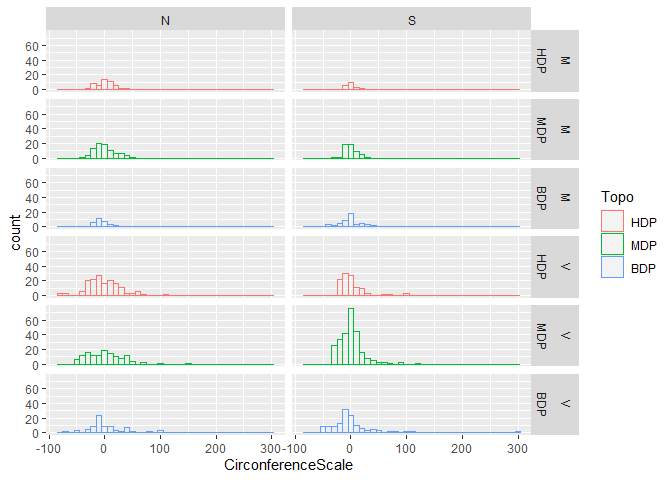

```r
p<- ggplot(circ2, aes(x=CirconferenceScale, color=Topo))+geom_histogram(fill="white", alpha=0.1, position="identity",binwidth=10)
p+facet_grid(Etat*Topo~Exposition)
```

Ainsi, puisque les variances sont non différentes entre Nord et Sud en Bas De Pente, et non différentes ensuite dans le versant Nord, entre les topographies, et qu’il en est de même pour les moyennes, on peut tracer deux groupes de distributions qui sont statistiquement différentes : les distributions Nord (HDP, MDP et BDP) avec la distribution Sud BDP, et les distributions Sud (HDP et MDP). Peut-on relier ces deux groupes de distributions à deux groupes d’espèces bien distincts ?

Enfin, il manque une dernière analyse, mais avant il faut expliquer un peu de théorie.

D’après des études sur les âges des arbres vivants et des arbres morts, il est possible d’identifier deux dynamiques de populations principales en forêt.

La première est une dynamique de compétition entre les individus. Elle se traduit par des arbres vivants vieillissants, qui exploitent toutes les ressources et donc limitent le développement des jeunes arbres. Dans ce cas, on retrouve une distribution en âge plutôt étalée pour les arbres vivants, allant jusqu’à des grands âges, tandis que les arbres morts sont principalement de petits arbres. Dans ce cas, on peut alors supposer que la variance des arbres vivants sera statistiquement plus grande que celle des arbres morts.

A l’inverse, on peut identifier une dynamique de renouvellement de la population. Elle se traduit par la mort occasionnelle de grands arbres, qui laissent alors la place aux jeunes. Dans ce cas, on retrouve relativement peu de petits arbres morts, potentiellement de grands arbres morts (en fonction de la cause, naturelle ou humaine, de la mort) tandis que les arbres vivants peuvent avoir une distribution assez étalée. Dans ce cas, on peut alors supposer que la variance des arbres vivants sera statistiquement non différente de cette des arbres morts.

Bien évidemment, ces interprétations statistiques sont des modèles, non vérifiés qui plus est, mais ils pourraient être testés. Dans le cas où ils étaient vrais, on pourrait alors interprêter les différences statistiques de variance entre les distributions des arbres vivants et celles des morts.

Voici un histogramme pour rappeler ces distributions :

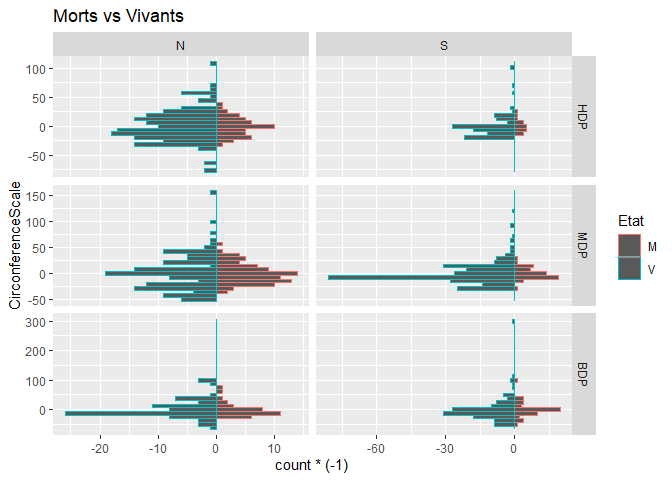

```r
p<- ggplot(circ2, aes(x=CirconferenceScale, color=Etat))+geom_histogram(data=subset(circ2,Etat=="M"))+geom_histogram(data=subset(circ2,Etat=="V"),aes(y=..count..*(-1),binwidth=10))+coord_flip()+ggtitle("Morts vs Vivants")
p+facet_grid(Topo~Exposition,scales="free")
```

Ainsi, d’après les tests statistiques : -Il n’y a pas de différence de variance entre les arbres morts et vivants, au sud comme au nord, en topographie BDP. Si notre modèle est vérifié, alors on peut supposer que la dynamique principale en BDP est celle d’un renouvellement de population. -En MDP, les variances sont statistiquement différente, au nord comme au sud, ce qui suggère une dynamique principale de compétition entre les individus. Il semble donc y avoir un effet de la topographie sur la dynamique de population d’arbres. -En HDP cependant, le résultat est mitigé : il y a une différence statistique observée au Nord, mais pas au Sud. On peut alors supposer un effet de l’exposition sur la dynamique de population.